# Vienna Elections 2020: Age profile of electoral candidates

Stadt

1. VOLT

1991.5

1992.12

2.95

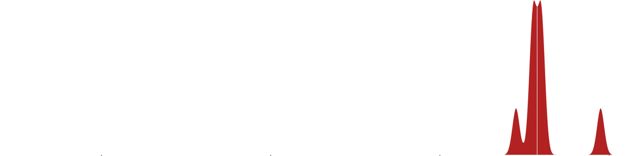

2. LINKS

1987.0

1981.74

13.88

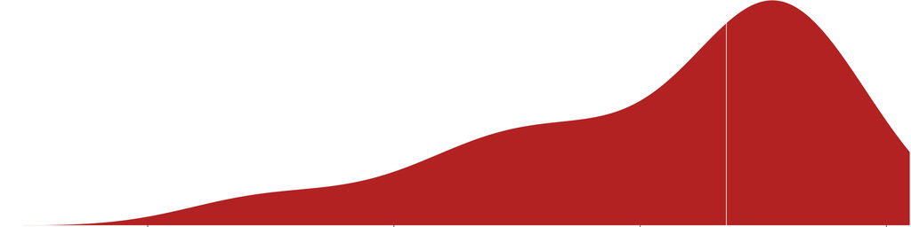

3. BIER

1986.0

1984.70

6.52

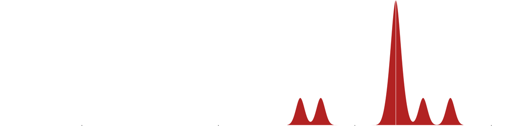

4. SÖZ

1984.5

1983.65

11.38

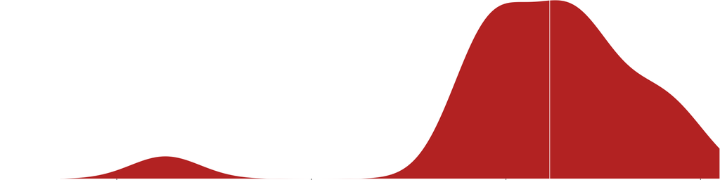

5. ÖVP

1977.0

1976.58

15.48

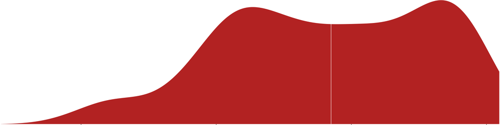

6. NEOS

1976.5

1977.02

13.89

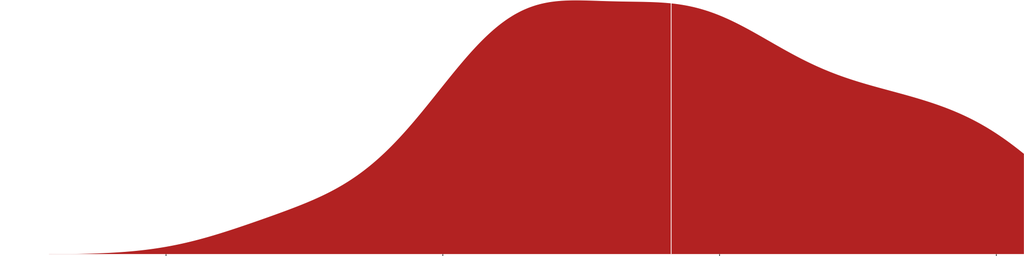

7. SPÖ

1976.0

1975.51

13.18

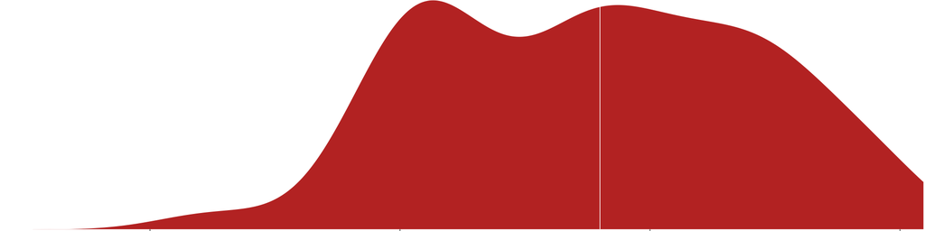

8. GRÜNE

1973.0

1973.79

12.25

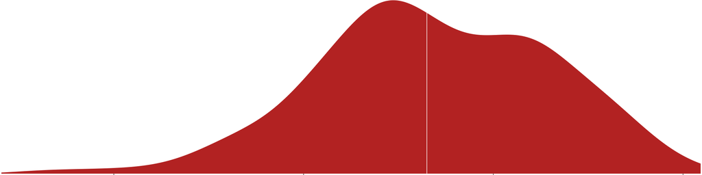

9. PRO

1970.0

1966.60

9.40

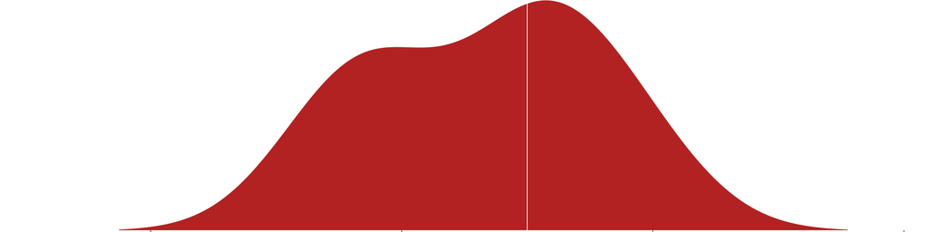

10. FPÖ

1968.0

1969.77

15.82

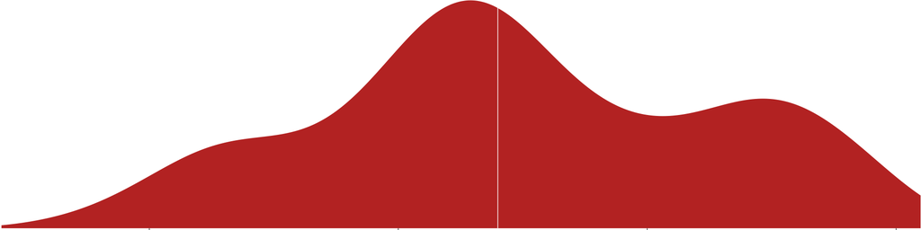

11. HC

1967.0

1968.61

13.00

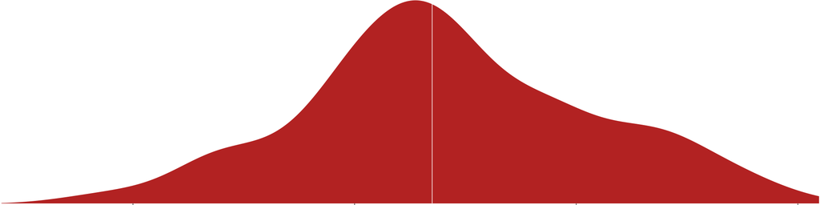

data: https://www.wien.gv.at/politik/wahlen/grbv/2020/ analysis: Roland Schmidt | @zoowalk | https://werk.statt.codes

<sup>1</sup> Vertical white line indicates median.

I won’t dig into every details, so only a few general remarks: On the city council level (‘Gemeinderat’) the established parties (SPÖ, FPÖ, Greens, ÖVP, Neos) feature (on average) somewhat older candidates than other, newer parties. On the district level (‘Bezirksvertretungen’), the former are occupying more of a middle ground. Among them, Neos’ candidates are on average younger, FPÖ candidates older. Funnily, when ranking parties according their median age, FPÖ and Team HC Strache (=former leader of FPÖ) are always adjacent.

## 4.3 Average birth year per electoral districts

Let’s now take up a ‘geographical perspective’ and see how birth years are distributed within electoral districts and the difference between the latter.

**Code: birth years by electoral districts**

```r
df_pl <- df_clean %>%
  group_by(election) %>%
  mutate(year_median_election=median(year_birth, na.rm=T)) %>%
  group_by(election, wahlkreis) %>%
  mutate(year_median_wahlkreis=median(year_birth, na.rm=T)) %>%
  mutate(year_mean_wahlkreis=mean(year_birth, na.rm=T)) %>%
  mutate(year_sd_wahlkreis=sd(year_birth, na.rm=T)) %>%
  ungroup() %>%
  mutate(wahlkreis_fct=fct_reorder(wahlkreis, year_median_wahlkreis))

ls_pl <- df_pl %>%
  group_split(election) %>%
    imap(~ggplot(data=.x)+
           labs(title=glue::glue("WIEN-WAHLEN 2020 <span style=color:firebrick>{unique(.x$election)}</span>:<br>Verteilung des Geburtsjahres von KandidatInnen pro Wahlbezirk"),
      subtitle="Median bei vertikaler weißer Linie.",
       x="Geburtsjahr",
       caption=my_caption)+
  ggridges::geom_density_ridges(aes(y=wahlkreis_fct,
                                     x=year_birth),
                                 fill="firebrick",
                                 scale=2,
                                rel_min_height = 0.01,
                                quantile_lines=T,
                                quantiles=2,
                                color="white")+
  geom_text(aes(y=length(unique(.x$wahlkreis)),
            x=2010),
            label="Median",
            nudge_y=+1.5,
            size = 3,
            check_overlap = T,
            hjust=0)  +

  geom_text(aes(y=length(unique(.x$wahlkreis)),
            x=2020),
            label="Mean",
            check_overlap = T,
            nudge_y=+1.5,
            size = 3,
            hjust=0)  +

  geom_text(aes(y=length(unique(.x$wahlkreis)),
            x=2030),
            label="SD",
            nudge_y=+1.5,
            size = 3,
            check_overlap = T,
            hjust=0)  +

  geom_text(aes(y=wahlkreis_fct,
                x=2010,
                label=glue::glue("{year_median_wahlkreis}")),
            check_overlap = T,
            size = 3,
            color = "grey50",
            hjust=0,
            nudge_y = 0.5
            )+
  geom_text(aes(y=wahlkreis_fct,
                x=2020,
                label=glue::glue("{round(year_mean_wahlkreis, digits=1)}")),
            check_overlap = T,
            size = 3,
            color = "grey50",
                        size=9,
            hjust=0,
            nudge_y = 0.5
            )+
          geom_text(aes(y=wahlkreis_fct,
                x=2030,
                label=glue::glue("{round(year_sd_wahlkreis, digits=2)}")),
            check_overlap = T,
            size = 3,
            color = "grey50",
            hjust=0,
            nudge_y = 0.5
            )+
  scale_y_discrete(labels=function(x) {stringr::str_remove(x, regex("___.*")) %>%
      str_trunc(., width=10, side="right", ellipsis = "...")},
      expand=expansion(mult=c(0,.1)))+
  scale_x_continuous(limits=c(1925, 2030),
                     breaks=seq(1950, 2000, 10),
                     expand=expansion(mult=c(0,.10)))+
  theme_post()+
  theme(legend.position="none",
        axis.title.x=element_text(hjust=0.7),
        axis.text.y=element_text(vjust=0)))
```

[figure not shown]

There is quite a difference in the median value between Ottakring (the youngest, 1979) and Donaustadt (the oldest, 1970.5). But then again the median value is just an aggregate value and conveys only a bit of the wider picture. I think the distribution curves are more telling. Whether that’s useful information or not, I am not entirely sure. At least it’s something, I have not seen before.

**Plot: District Councils**

[figure not shown]

**Plot: City electoral proposal**

[figure not shown]

## 4.4 Average birth year per electoral district and party

Now let’s dig deeper and see for the distribution of birth years by electoral districts and parties, again for each election (city council, district councils).

### 4.4.1 Graph

Hover with the mouse over the box plot and dots to obtain the pertaining data.

**Code: graph**

```r
df_age_list_district_graph <- df_clean %>%
  filter(!str_detect(election, "Stadt")) %>%
  group_by(election, wahlkreis, party) %>%
  mutate(year_median=median(year_birth, na.rm=T),
    year_mean=mean(year_birth, na.rm=T),
    year_se=sd(year_birth, na.rm=T),
    values_nested=list(year_birth=year_birth)) %>%
  group_by(election) %>%
  mutate(median_election=median(year_birth, na.rm = T)) %>%
  group_by(election, wahlkreis) %>%
  mutate(median_wahlkreis=median(year_birth, na.rm=T)) %>%
  ungroup() %>%
  mutate(wahlkreis_num=str_extract(wahlkreis, regex("\\d+")) %>% as.numeric()) %>%
  mutate(wahlkreis_fac=fct_reorder(wahlkreis, wahlkreis_num)) %>%
  mutate(party=fct_rev(party))


ls_age_list_district_graph <- df_age_list_district_graph %>%
  mutate(election=fct_relevel(election, "Gemeinderat", "Bezirksvertretungen")) %>%   group_split(election) %>%
  imap(~ggplot(data=.x)+
         labs(title=glue::glue("WIEN-WAHL 2020: <span style=color:firebrick>{unique(.x$election)}</span><br>Verteilung des Geburtsjahres pro Wahlbezirk und Partei"),
              #subtitle="Geburtsjahr als proxy für Alter.",
              x="Geburtsjahr",
              caption=my_caption)+
  geom_jitter_interactive(aes(y=tidytext::reorder_within(
    x=party,
    by=year_median,
    within=wahlkreis_fac
  ),
                              x=year_birth,
                              tooltip=glue::glue("{name}
                                                 {party}
                                                 {year_birth}"),
                              data_id=paste(name)),
              color="grey50",
              size=.5,
              alpha=0.5)+
  geom_boxplot_interactive(aes(
    y=tidytext::reorder_within(
    x=party,
    by=year_median,
    within=wahlkreis_fac
  ),
                               x=year_birth,
                               tooltip=glue::glue("{party}
                                                  Median: {year_median}
                                                  arith Mittelw.: {round(year_mean, 2)}
                                                  Std.Abw.: {round(year_se,2)}"),
                               data_id=paste(wahlkreis, party)),
               outlier.shape = NA,
               size=.2,
               color="#374E55FF",
               fill=NA)+
  geom_vline(aes(xintercept=median_election,
                 color="color_vline",
                 group=wahlkreis,
                 name=""),
             #key_glyph=c("vline"),
             linetype="dotted"
             )+
  scale_color_manual(labels=c(color_vline="median of all candidates"),
                     values=c(color_vline="firebrick"))+
  scale_x_continuous(labels=function(x) str_sub(x, start=3),
                     breaks=seq(1940, 2000, 20))+
  tidytext::scale_y_reordered()+
  facet_wrap(vars(wahlkreis_fac),
             scales="free",
             ncol=4,
             labeller=as_labeller(function(x) str_trunc(x,
                                                        width=15,
                                                        side=c("right"),
                                                        ellipsis="...")
                                  )
             )+
  theme_post()+
  theme(
    panel.grid.major.y = element_blank(),
    axis.text.y = element_markdown(size=6),
    axis.text.x = element_markdown(size=6),
    axis.title.x = element_markdown(size=6),
    legend.position = "top",
    legend.justification = "left",
    legend.title=element_blank()
  ))
```

[interactive chart not shown]

**Graph: Bezirksvertretung**

[interactive chart not shown]

### 4.4.2 Table

Below essentially the same information as provided in the graph above but in a tabular form.

**Code: Avg. birth year of lists by district**

```r
df_age_list_district <- df_clean %>%
  #filter(!str_detect(election, "Stadt")) %>%
  group_by(election, wahlkreis, party) %>%
  summarize(year_median=median(year_birth, na.rm=T),
    year_mean=mean(year_birth, na.rm=T),
    year_se=sd(year_birth, na.rm=T),
    values_nested=list(year_birth=year_birth)) %>%
  ungroup() %>%
  mutate(values_df=map(values_nested, as_tibble_col, column_name ="birth_year"))

tb_age_list_district <- df_age_list_district %>%
  reactable(.,
            columns=list(election=colDef(name="Wahl"),
                         wahlkreis=colDef(name="Wahlkreis"),
                         party=colDef(name="Partei",
                                      width=70),
                         year_median=colDef(name="Median",
                                            format=colFormat(digits=1)),
                         year_mean=colDef(name="arith. Mittel",
                                          format=colFormat(digits=1)),
                         values_nested=colDef(show = F),
                         values_df=colDef(show = F),
                         year_se=colDef(name="Std.Abw.",
                                        format=colFormat(digits=1))),
            bordered=F,
            compact = TRUE,
            highlight = TRUE,
            style = list(fontSize = "10px"),
            filterable = TRUE,
            theme = reactableTheme(
                            borderWidth = 1,
                            borderColor = "#7f7f7f",
                            backgroundColor = plot_bg_color,
                            filterInputStyle = list(
                              color="green",
                              backgroundColor = plot_bg_color))
            ) %>%
            add_title(title="WIEN-WAHL 2020: Durchschnittliches Alter pro Wahlbezirk") %>%
            add_source(source="Geburtsjahr lt. Wahlvorschlag als Basis.")
```

WIEN-WAHL 2020: Durchschnittliches Alter pro Wahlbezirk

| Wahl | Wahlkreis | Partei | Median | arith. Mittel | Std.Abw. |
| --- | --- | --- | --- | --- | --- |
| Gemeinderat | Brigittenau | SPÖ | 1975.5 | 1975.16666666667 | 14.3579774046178 |
| Gemeinderat | Brigittenau | FPÖ | 1965.5 | 1966.83333333333 | 13.6503968196288 |
| Gemeinderat | Brigittenau | GRÜNE | 1980 | 1981.09090909091 | 8.65395337928909 |
| Gemeinderat | Brigittenau | ÖVP | 1973 | 1975.81818181818 | 15.0852125064129 |
| Gemeinderat | Brigittenau | NEOS | 1964.5 | 1968.66666666667 | 7.84006802691575 |
| Gemeinderat | Brigittenau | BIER | 1980.5 | 1980.5 | 7.77817459305202 |
| Gemeinderat | Brigittenau | HC | 1978 | 1974.11111111111 | 11.5914240329267 |
| Gemeinderat | Brigittenau | LINKS | 1986 | 1982.3 | 11.3827354650219 |
| Gemeinderat | Brigittenau | SÖZ | 1987 | 1984.55555555556 | 7.76387646590141 |
| Gemeinderat | Donaustadt | SPÖ | 1972.5 | 1974.96666666667 | 11.9351215509848 |

[output cut: 390 more lines]

Geburtsjahr lt. Wahlvorschlag als Basis.

## 4.5 Birth year and position on electoral list

Another question which came to my mind: How is a candidate’s birth year/age related to his or her position on the electoral list. Are more senior candidates more likely to be on more attractive, i.e. top positions? Or is youth related to competitive positions? Are there any differences between the parties or elections (city vs district level) when it comes to this relation? Hover with the mouse over the individual dots to obtain data on indivdual candidates.

**Code: Age and position on electoral list**

```r
ls_pl_age_rank_district <- df_clean %>%
  group_split(election) %>%
  imap(~ggplot(data=.x)+
  labs(
    title=glue::glue("WIEN-WAHL 2020: <span style  = color:firebrick>{unique(.x$election)}</span><br>Listenplatz und Geburtsjahr"),
    subtitle="Loess regression.",
       x="Geburtsjahr",
       y="Listenplatz",
       caption=my_caption)+
  geom_jitter_interactive(aes(x=year_birth,
                              y=listenplatz,
                              tooltip=glue::glue("{name}
                                                 Geb.Jahr: {year_birth}
                                                 Listenplatz: {listenplatz}
                                                 Wahlkreis: {wahlkreis}
                                                 ")),
              color="grey50",
              alpha=0.2)+
  geom_smooth(aes(x=year_birth,
                  y=listenplatz),
                  method='loess',
              formula= y~x,
              linewidth=0.5,
              color="firebrick")+
    scale_x_continuous(labels=function(x) str_sub(x, start=3),
                     breaks=seq(1940, 2000, 20))+
  facet_wrap(vars(party))+
  theme_post()+
  theme(axis.title.x=element_text(size=6),
        axis.title.y=element_text(
          angle=90,
          size=6,
          color="grey50",
          hjust=1),
        axis.text.y = element_markdown(size=6),
        axis.text.x = element_markdown(size=6)))
```

**Plot: City Council - Age and position on electoral list**

[interactive chart not shown]

Interestingly, there are some subtle differences between the regression lines’ slope. Note how it increases for higher birth years for the SPÖ and the FPÖ. In other words, younger candidates tend to be on higher (less attractive) positions on the electoral list for these two parties. As for the other major parties, there is no comparable relation, at least not as visible as in the two previous cases. Obviously, this is purely descriptive.

To see the results for the other electoral levels unfold the sections below.

**Plot: District Councils - Age and position on electoral list**

[interactive chart not shown]

**Plot: City - Age and position on electoral list**

[interactive chart not shown]

## 4.6 Non-resident candidates

I could imagine that ‘non-residency’ conflates quite a number of factors, and the reasons and consequences of ‘non-residency’ are likely to be quite complex. A possible hypotheses could be that parties with high number of non-resident candidates are unevenly institutionalized across the city and hence have to bring in members from outside of the electoral district. But again, this is purely speculative and I haven’t thought, let alone read about it systematically. Nevertheless, as some kind of tentative inquiry, I thought it’s worth looking at the numbers. Three specific questions came to my mind: 1) Are there parties which feature particularly frequently such non-resident candidates? 2) Are there districts where non-resident candidates are particularly frequently running for office? 3) Do the shares of non-resident candidates differ between elections for the city council and for the district councils? I would think that the relation between a candidate and her electoral district, i.e. place of residence, is more of a significance in the latter case.

### 4.6.1 Share per party

**Code: Out-of-residence candidates per party and election**

```r
#party with most out-of-residence candidates
df_residence_party <- df_clean %>%
  filter(!str_detect(election, "Stadt")) %>%
  group_by(election, party, residence) %>%
  summarize(n_residence=n()) %>%
  mutate(rel_residence=n_residence/sum(n_residence, na.rm = T)) %>%
  filter(residence=="outside") %>%
  arrange(desc(rel_residence)) %>%
  ungroup()

#fn for barchart
bar_chart <- function(label, width = "100%", height = "16px", fill = "#00bfc4", background = NULL) {
  bar <- div(style = list(background = fill, width = width, height = height))
  chart <- div(style = list(flexGrow = 1, marginRight = "8px", background = background), bar)
  div(style = list(display = "flex", alignItems = "right"), chart, label)
}

#assemble table
tb_residence_party <- df_residence_party %>%
  select(party, everything()) %>%
  reactable(.,
            columns = list(
              party=colDef(name="Party"),
              election=colDef(name="Election"),
              residence=colDef(show=FALSE),
              n_residence = colDef(name = "Number",
                                   align = "left",
                                   cell = function(value) {
    width <- paste0(value / max(df_residence_party$n_residence) * 100, "%")
    value <- format(value, trim=F, width=3, justify = "right")
    bar_chart(value, width = width, fill = "#00bfc4")}),
                  rel_residence = colDef(name = "Share",
                                   align = "left",
                                   cell = function(value) {
    width <- paste0(value * 100, "%")
    value <- scales::percent(value)
    bar_chart(value, width = width, fill = "orange", background = "#e1e1e1")})),
    bordered=F,
    compact = TRUE,
    highlight = TRUE,
    style = list(fontSize = "10px"),
    filterable = TRUE,
    theme = reactableTheme(
      borderColor = "#7f7f7f",
      borderWidth = 1,
      backgroundColor = "#f0eff0",
      filterInputStyle = list(
                  color="green",
                  backgroundColor = plot_bg_color)
            )) %>%
            add_title(title="Parties' number and share of non-resident candidates per election") %>%
            add_source(source="Non-resident candidates: Candidates not residing in their electoral district according to their residency zip code.")
```

Parties' number and share of non-resident candidates per election

| Party | Election | Number | Share |
| --- | --- | --- | --- |
| WANDL | Bezirksvertretungen | 8 | 1 |
| VOLT | Bezirksvertretungen | 142 | 0.946666666666667 |
| VOLT | Gemeinderat | 15 | 0.9375 |
| BIER | Bezirksvertretungen | 42 | 0.893617021276596 |
| BIER | Gemeinderat | 31 | 0.861111111111111 |
| PdA | Bezirksvertretungen | 2 | 0.666666666666667 |
| VOLK | Bezirksvertretungen | 2 | 0.666666666666667 |
| HC | Bezirksvertretungen | 481 | 0.662534435261708 |
| SÖZ | Bezirksvertretungen | 90 | 0.647482014388489 |
| SÖZ | Gemeinderat | 83 | 0.619402985074627 |

[output cut: 19 more lines]

Non-resident candidates: Candidates not residing in their electoral district according to their residency zip code.

### 4.6.2 Share per electoral districts

**Code: Share of out-of-residence candidates per district**

```r
#share in districts
df_residence_district <- df_clean %>%
  filter(!str_detect(election, "Stadt")) %>%
  group_by(election, wahlkreis, residence) %>%
  summarize(n_residence=n()) %>%
  mutate(rel_residence=n_residence/sum(n_residence, na.rm = T)) %>%
  filter(residence=="outside") %>%
  ungroup() %>%
  arrange(election, desc(rel_residence))

#fn for barchart
bar_chart <- function(label, width = "100%", height = "16px", fill = "#00bfc4", background = NULL) {
  bar <- div(style = list(background = fill, width = width, height = height))
  chart <- div(style = list(flexGrow = 1, marginRight = "8px", background = background), bar)
  div(style = list(display = "flex", alignItems = "right"), chart, label)
}

#assemble table
tb_residence_district <- df_residence_district %>%
  reactable(.,
            columns = list(
              election=colDef(name="Election"),
              wahlkreis=colDef(name="Electoral district"),
              residence=colDef(show=FALSE),
              n_residence = colDef(name = "Number",
                                   align = "left",
                                   cell = function(value) {
    width <- paste0(value / max(df_residence_district$n_residence) * 100, "%")
    value <- format(value, trim=F, width=3, justify = "right")
    bar_chart(value, width = width, fill = "#00bfc4")}),

              rel_residence = colDef(name = "Share",
                                   align = "left",
                                   cell = function(value) {
    # width <- paste0(value / max(df_residence_district$rel_residence) * 100, "%")
    width <- paste0(value * 100, "%")
    value <- scales::percent(value)
    bar_chart(value, width = width, fill = "orange", background = "#e1e1e1")})),
    bordered=F,
    compact = TRUE,
    highlight = TRUE,
    style = list(fontSize = "10px"),
    filterable = TRUE,
    theme = reactableTheme(
      borderColor = "#7f7f7f",
      borderWidth = 1,
      backgroundColor = "#f0eff0",
      filterInputStyle = list(
                  color="green",
                  backgroundColor = plot_bg_color)
            )) %>%
            add_title(title="Share of non-resident candidates per electoral district")
```

Share of non-resident candidates per electoral district

| Election | Electoral district | Number | Share |
| --- | --- | --- | --- |
| Gemeinderat | Hernals | 35 | 0.573770491803279 |
| Gemeinderat | Währing | 28 | 0.482758620689655 |
| Gemeinderat | Zentrum | 61 | 0.458646616541353 |
| Gemeinderat | Leopoldstadt | 43 | 0.457446808510638 |
| Gemeinderat | Meidling | 42 | 0.451612903225806 |
| Gemeinderat | Innen-West | 45 | 0.428571428571429 |
| Gemeinderat | Döbling | 31 | 0.397435897435897 |
| Gemeinderat | Rudolfsheim-Fünfhaus | 25 | 0.390625 |
| Gemeinderat | Brigittenau | 32 | 0.390243902439024 |
| Gemeinderat | Penzing | 33 | 0.370786516853933 |

[output cut: 31 more lines]

### 4.6.3 City council vs district councils

Finally, let’s contrast parties’ non-resident candidate ratios for the election to the city council and the district councils.

**Code: City vs district councils**

```r
diff_share_non_residency <- df_clean %>%
  filter(!str_detect(election, "Stadt")) %>%
  group_by(election, party, residence) %>%
  summarize(n_residence=n()) %>%
  mutate(rel_residence=n_residence/sum(n_residence, na.rm = T)) %>%
  filter(residence=="outside") %>%
  ungroup() %>%
  group_by(party) %>%
  mutate(n_elections=n()) %>%
  filter(n_elections==2)

diff_share_non_residency_wide <- diff_share_non_residency %>%
  pivot_wider(id_cols=party, names_from=election,
              values_from=rel_residence) %>%
  mutate(city_larger_district=case_when(Gemeinderat > Bezirksvertretungen ~ "GR größer",
                                        Gemeinderat <  Bezirksvertretungen ~ "GR kleiner"))
```

```r
pl_diff_share_non_residency<- diff_share_non_residency %>%
  drop_na() %>%
  ggplot()+
  labs(title=glue::glue("WIEN-WAHL 2020: Share of non-resident candidates per party.<br><span style=color:{paletteer_d('ggsci::default_jama')[2]}>City council (Gemeinderat)</span> vs <span style=color:{paletteer_d('ggsci::default_jama')[3]}>district councils (Bezirksräte)</span>"),
  subtitle="Non-resident candidates: Candidates with different residence zip-code than their electoral district",
  x="Share of non-resident candiates",
  caption=my_caption)+
  geom_segment(data=diff_share_non_residency_wide,
               aes(y=reorder(party, -Gemeinderat),
                   yend=reorder(party, -Gemeinderat),
                 x=Gemeinderat,
                 xend=Bezirksvertretungen),
               color="grey50")+
  geom_point(aes(y=reorder(party, -rel_residence),
                 x=rel_residence,
                 shape=election,
                 color=election),
             size=2)+
  scale_color_manual(values=c("Gemeinderat"=paletteer_d("ggsci::default_jama")[c(2)],
                          "Bezirksvertretungen"=paletteer_d("ggsci::default_jama")[c(3)]),
                          label=c("Gemeinderat"="City council",
                                  "Bezirksvertretungen"="District councils"))+
  scale_shape(guide="none")+
  scale_x_percent()+
  theme_post()+
  theme(legend.position = "none",
        legend.direction = "horizontal",
        legend.title=element_blank(),
        panel.grid.major.y = element_blank(),
        panel.grid.major.x = element_line())
```

[figure not shown]

The graph shows that almost all parties feature a smaller share of non-resident candidates in the elections to the city council than in the elections to the district councils. This difference is particularly strong for the FPÖ and for Team HC Strache. However, there are two notable exceptions. On is WIFF - Wir für Floridsdorf, a party with a clear programmatic focus for one specific district. Hence, it doesn’t come as a surprise that the share of non-resident candidates for the district council is low. The second exceptions are the Greens. I am second guessing here, but I could imagine that this is indicative for a strong ‘grass-root’, locally based party organization and reflecting the engagement of candidates who actually live in their electoral districts. I find the graph in any case quite noteworthy.

# 5 Wrap-up

So that’s it for now. Again, this has been largely about retrieving and crunching numbers, but I guess some bits are worth entertaining more substantively.